# Exploration of contribution for Presidential Election in 2016

This report explores data of contributions in California state for Presidential election in 2016.

SUMMARY OF DATA

```
## 'data.frame':    731695 obs. of  19 variables:
##  $ cmte_id          : Factor w/ 24 levels "C00458844","C00500587",..: 6 7 6 7 7 6 6 7 7 6 ...
##  $ cand_id          : Factor w/ 24 levels "P00003392","P20002671",..: 1 12 1 12 12 1 1 12 12 1 ...
##  $ cand_nm          : Factor w/ 24 levels "Bush, Jeb","Carson, Benjamin S.",..: 4 19 4 19 19 4 4 19 19 4 ...
##  $ contbr_nm        : Factor w/ 121014 levels " ALERIS, ANNAKIM",..: 57630 61743 36848 62538 62538 75712 4917 62555 62563 107749 ...
##  $ contbr_city      : Factor w/ 1544 levels "","*MORENO VALLEY",..: 1250 196 1453 1116 1116 241 1094 1466 1497 1320 ...
##  $ contbr_st        : Factor w/ 1 level "CA": 1 1 1 1 1 1 1 1 1 1 ...
##  $ contbr_zip       : Factor w/ 100530 levels "","0","11205",..: 13247 47055 46804 12151 12151 70481 26484 32158 43750 91433 ...
##  $ contbr_employer  : Factor w/ 40107 levels "","'K' LINE AMERICA",..: 23536 2715 28769 37997 37997 23536 31111 25174 24367 33320 ...
##  $ contbr_occupation: Factor w/ 18190 levels "","''RETIRED''",..: 13650 15172 13188 11450 11450 13650 8098 12519 10583 12446 ...
##  $ contb_receipt_amt: num  100 40 80 35 100 ...
##  $ contb_receipt_dt : Factor w/ 548 levels "1-Apr-15","1-Apr-16",..: 460 458 155 475 493 85 137 458 475 171 ...
##  $ receipt_desc     : Factor w/ 73 levels "","* EARMARKED CONTRIBUTION: SEE BELOW REATTRIBUTION/REFUND PENDING",..: 1 1 1 1 1 1 1 1 1 1 ...
##  $ memo_cd          : Factor w/ 2 levels "","X": 2 1 2 1 1 2 2 1 1 2 ...
##  $ memo_text        : Factor w/ 302 levels "","$1,050 REFUNDED ON 7/7/2016",..: 51 26 51 26 26 51 51 26 26 51 ...
##  $ form_tp          : Factor w/ 3 levels "SA17A","SA18",..: 2 1 2 1 1 2 2 1 1 2 ...
##  $ file_num         : int  1079219 1077404 1079219 1077404 1077404 1079219 1079219 1077404 1077404 1079219 ...
##  $ tran_id          : Factor w/ 728999 levels "A000771210424405B8CF",..: 166920 472085 168768 473529 475830 167863 171575 471547 473525 169493 ...
##  $ election_tp      : Factor w/ 4 levels "","G2016","P2016",..: 3 3 3 3 3 3 3 3 3 3 ...
##  $ X.               : logi  NA NA NA NA NA NA ...
```

NAME OF COLUMNS IN DATA

```
##  [1] "cmte_id"           "cand_id"           "cand_nm"
##  [4] "contbr_nm"         "contbr_city"       "contbr_st"
##  [7] "contbr_zip"        "contbr_employer"   "contbr_occupation"
## [10] "contb_receipt_amt" "contb_receipt_dt"  "receipt_desc"
## [13] "memo_cd"           "memo_text"         "form_tp"
## [16] "file_num"          "tran_id"           "election_tp"
## [19] "X."
```

# Univariate Plots Section

```
##     Min.  1st Qu.   Median     Mean  3rd Qu.     Max.
## -10500.0     15.0     27.0    124.5     75.0  10800.0
```

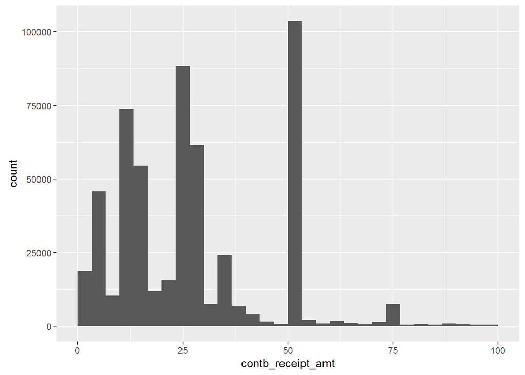

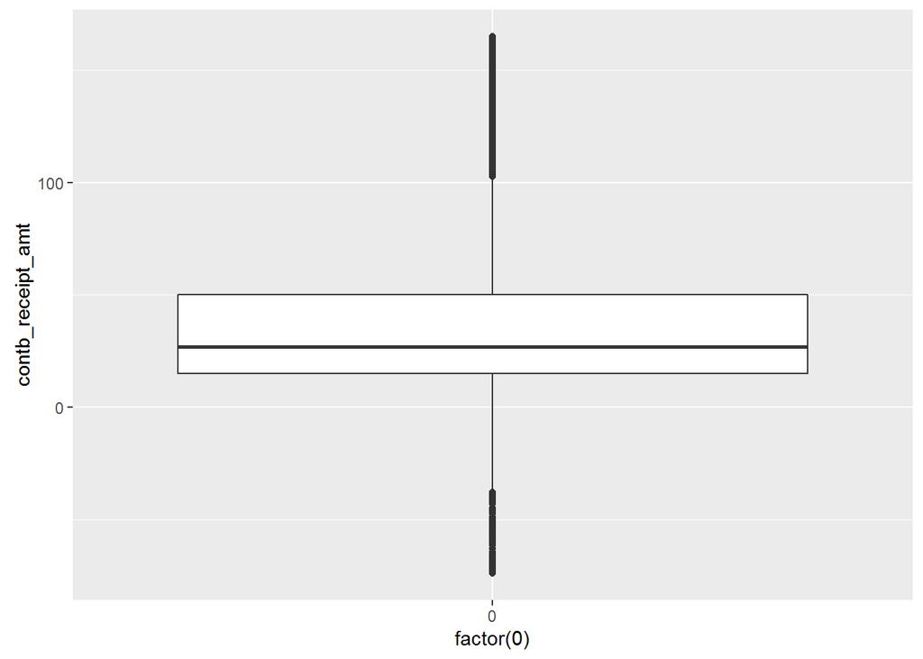

```
## [1] 24
```

```
##
##          Sanders, Bernard   Clinton, Hillary Rodham
##                    399963                    209535
## Cruz, Rafael Edward 'Ted'       Carson, Benjamin S.
##                     57152                     27342
##              Rubio, Marco          Trump, Donald J.
##                     14092                      5142
##            Fiorina, Carly                Paul, Rand
##                      4696                      4259
##                 Bush, Jeb           Kasich, John R.
##                      3115                      3005
##             Walker, Scott            Huckabee, Mike
##                       717                       531
##   O'Malley, Martin Joseph          Lessig, Lawrence
##                       397                       372
##        Graham, Lindsey O.  Christie, Christopher J.
##                       345                       333
##               Stein, Jill             Johnson, Gary
##                       197                       141
##    Perry, James R. (Rick)     Webb, James Henry Jr.
##                       116                       106
##      Santorum, Richard J.             Jindal, Bobby
##                        85                        31
##         Pataki, George E.     Gilmore, James S IIII
##                        20                         3
```

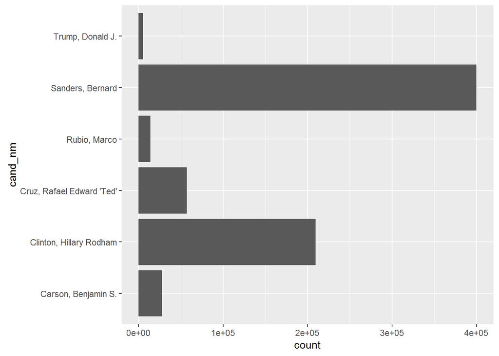

There are total 24 candidates. Bernard Sanders got most contributions followed by Hillary Clinton.

```
## [1] 1544
```

```
##
##   LOS ANGELES SAN FRANCISCO     SAN DIEGO       OAKLAND      SAN JOSE
##         55763         49345         26007         18521         17494
##      BERKELEY
##         13971
```

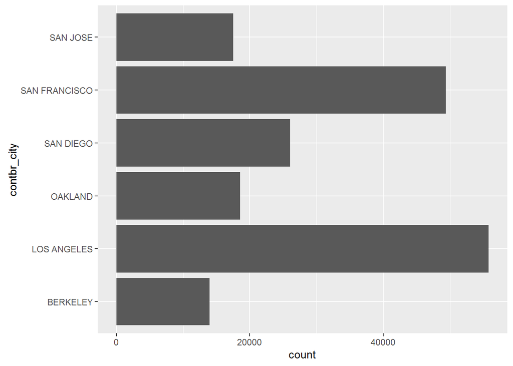

```
##         Min.      1st Qu.       Median         Mean      3rd Qu.
## "2013-11-05" "2016-02-05" "2016-03-23" "2016-03-08" "2016-05-01"
##         Max.
## "2016-06-30"
```

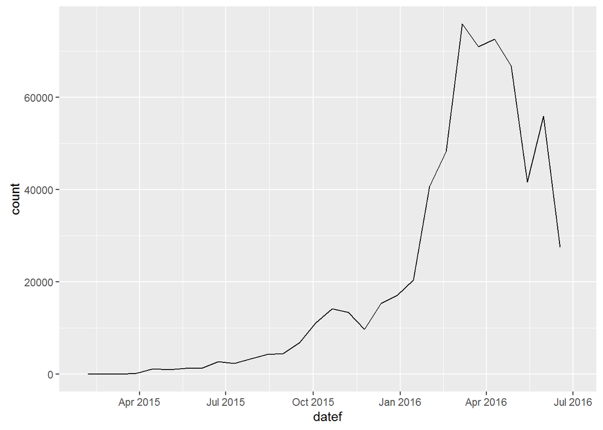

We see that minimum contribution date is on 5th November, 2013, while maximum date is on 30th June, 2016. Numbers of contributions is contiuously rising and in 2016 there is steep increase in contributions and reaches its peak in March, 2016.

```
##
##      NOT EMPLOYED           RETIRED           TEACHER          ATTORNEY
##            102442             98286             16223             12816
##          ENGINEER SOFTWARE ENGINEER         PHYSICIAN         PROFESSOR
##              9720              8928              6671              6352
```

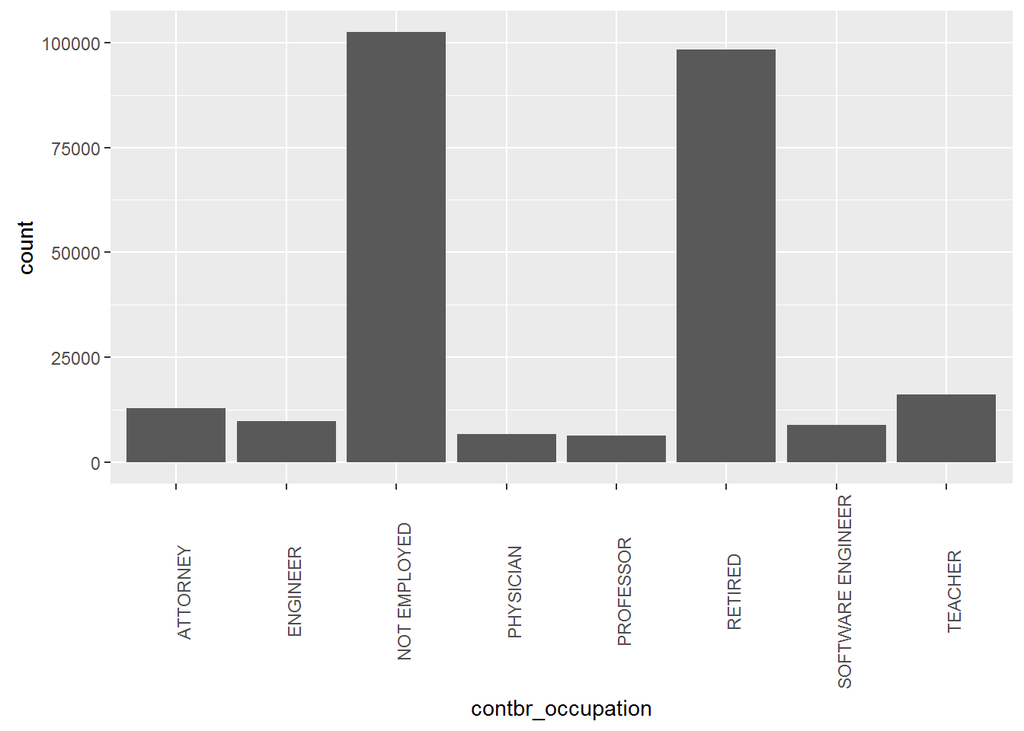

Surprisingly most of contributors are unemployed or retired. It might be due to fact that contributors want to maintain privacy of their occupation.

# Univariate Analysis

### What is the structure of your dataset?

- Sanders, Bernard
- Clinton, Hillary Rodham
- Cruz, Rafael Edward ‘Ted’
- Carson, Benjamin S.
- Rubio, Marco
- Trump, Donald J.

Top 6 cities, who gave maximum numbers of contribution in decreasing order are

- LOS ANGELES
- SAN FRANCISCO
- SAN DIEGO
- OAKLAND
- SAN JOSE
- BERKELEY

We see that above are also highly populated cities of California and this might be reason for high contributions there.

Top 8 occupations(contbr_occupation) of biggest contributorts are below in decreasing order

- NOT EMPLOYED
- RETIRED
- TEACHER
- ATTORNEY
- ENGINEER
- SOFTWARE ENGINEER
- PHYSICIAN
- PROFESSOR

Contributions started from November, 2013 and contribution data is availabe till June, 2016. Date is specified in column contb_receipt_dt.

### What is/are the main feature(s) of interest in your dataset?

Main features of interest in dataset are ammount received (contbr_receipt_amt) and candidate (cand_nm).

### What other features in the dataset do you think will help support your investigation into your feature(s) of interest?

Other features like candidate city(contbr_city), date of donation(contb_receipt_date) and contributor occupation (contbr_occupation) support in investigation of candidates who received highest contributions.

### Did you create any new variables from existing variables in the dataset?

I didn’t create any new variable, but cleaned the data and recorded that we could add features like gender and party (democratic or republican) for deeper exploration of data.

### Of the features you investigated, were there any unusual distributions? Did you perform any operations on the data to tidy, adjust, or change the form of the data? If so, why did you do this?

We did following operations to clean the data

- removed outliers from contribution amout (contb_receipt_amt) by removing donations lying outside of 1.5 times interquantile range.
- Collected lists of top cities, candidates and occupations to explore relations in tractable way as most of contributions are centered there.
- converted contribution date into a R date type, so that it could be explored in R synatx.

# Bivariate Plots Section

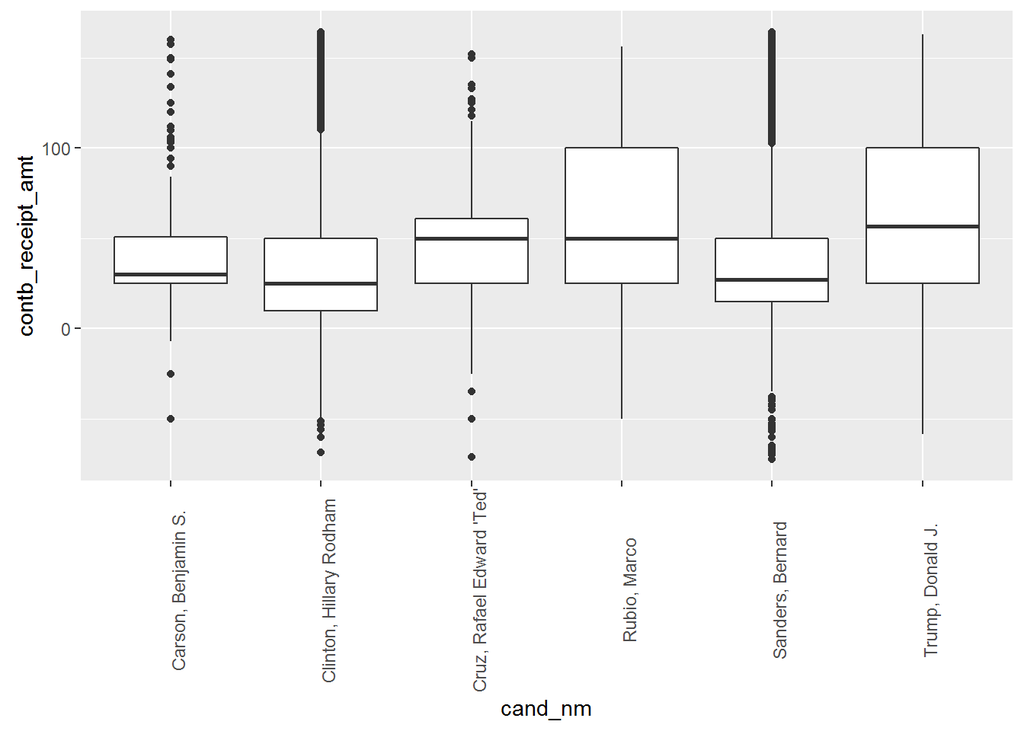

We see that most of contribution amount is between 0 and 100 for all candidates, though we see that data quantile range is expanded for Donald Trump and Marco Rubio.

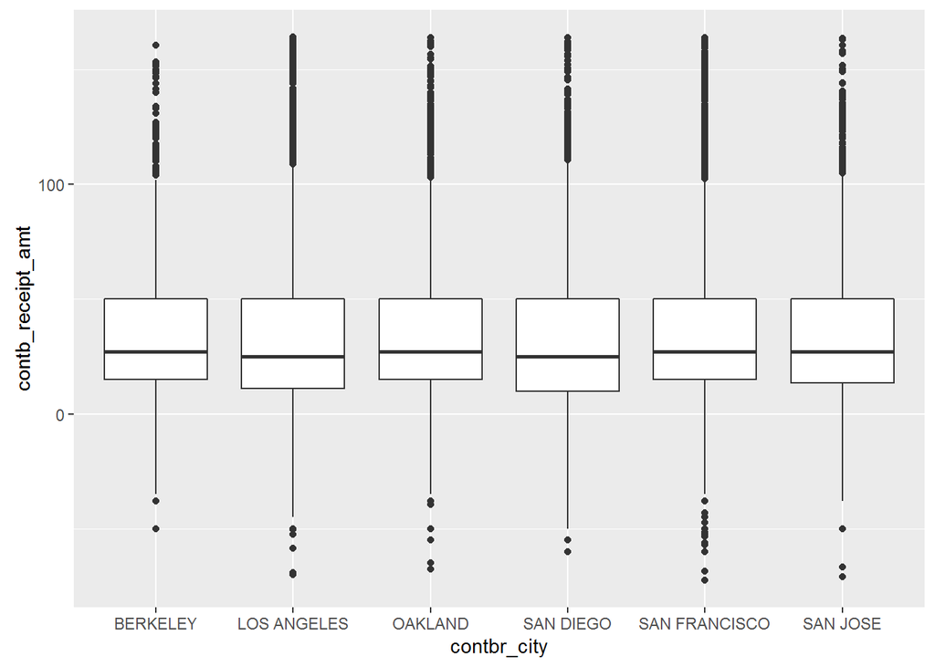

We see that there is no variation in type of contribution received between different cities.

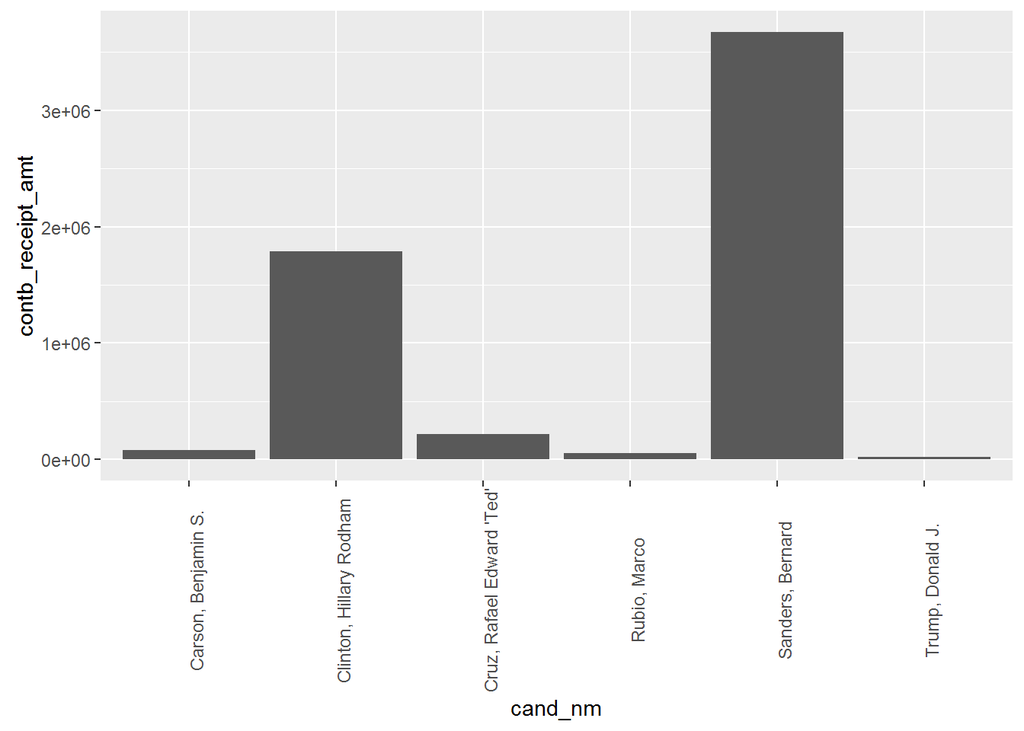

We see that Bernard Sanders received highest amount of contribution followed by Hillary Clinton. This corresponds to number of donations in univariate analysis.

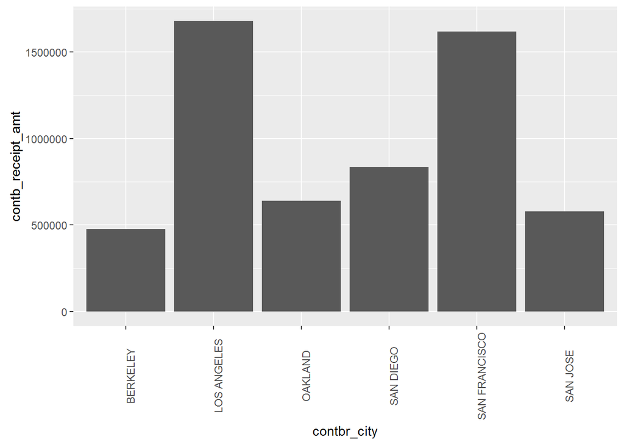

We see that Los Angeles received highest amount of contribution followed by San Francisco.

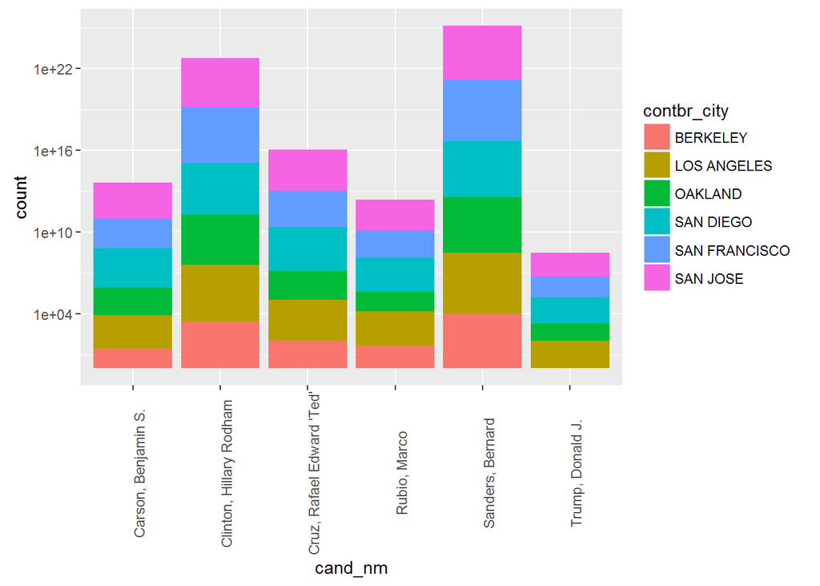

We don’t see any candidate getting preference in a particular city.

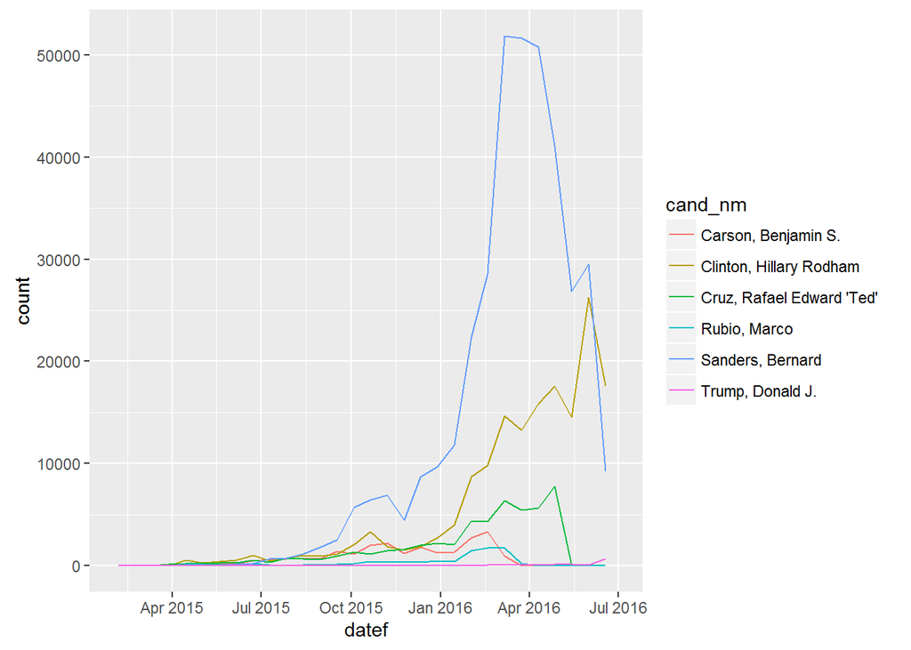

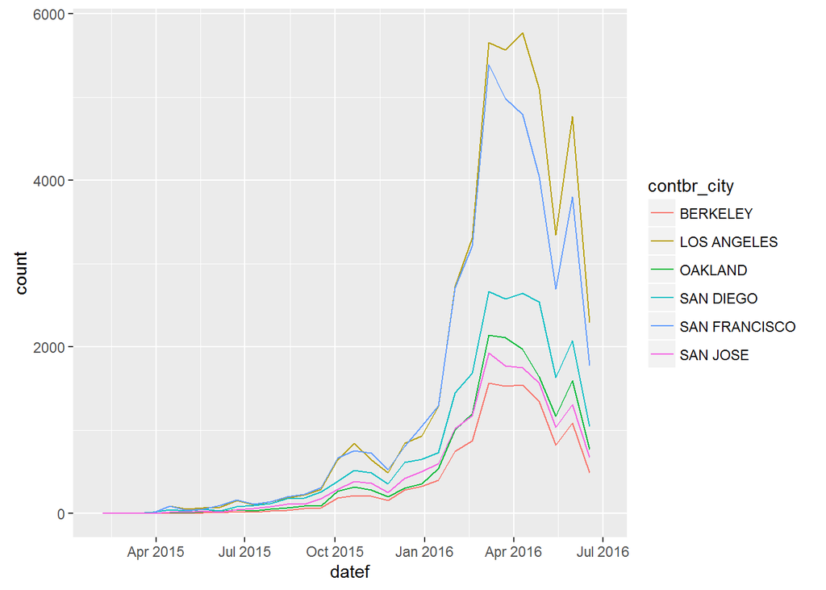

We don’t see any anomaly in number of contributions with respect to city and they tend to follow general pattern.

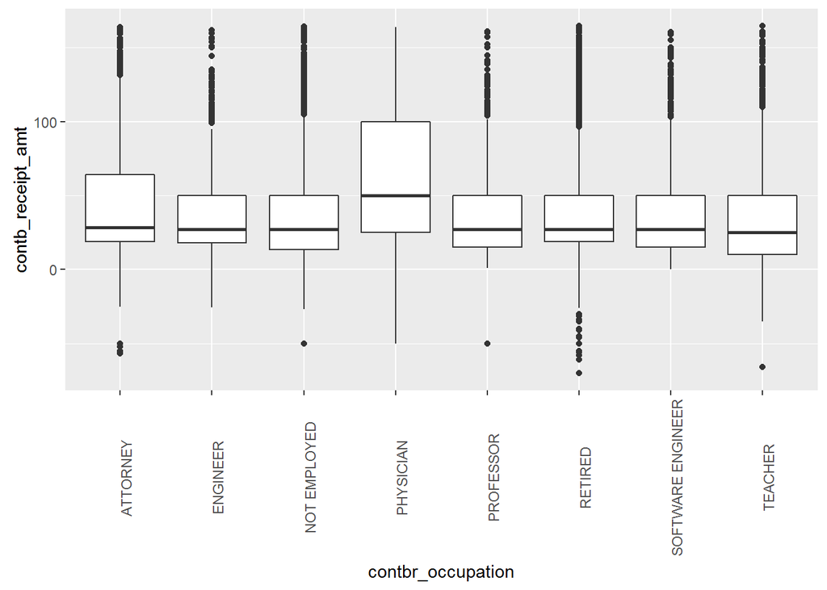

Individual contribution amout is low and doesn’t vary with occupation except physician who seems to have higher individual contribution amount.

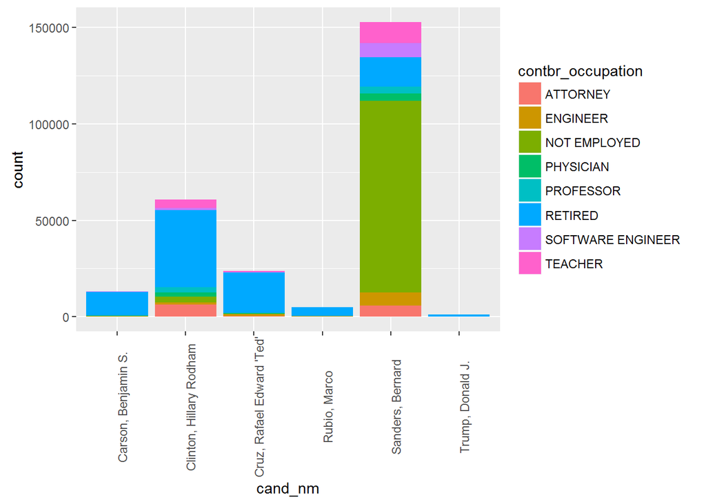

We see that most of unemployed contributed to Sanders, while Clinton has most contribution from retired.

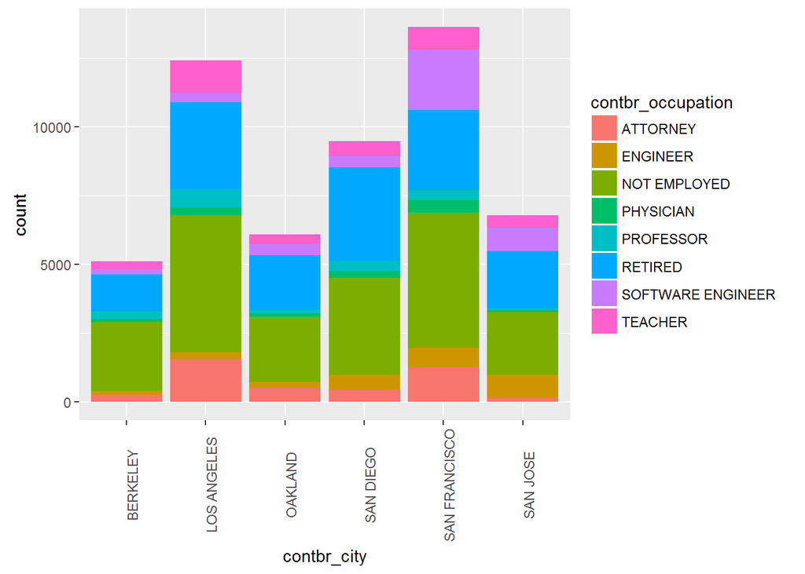

In general, there is no variation in occupation type across cities except San Francisco and San Jose tends to have more Software Engineer, which can be attributed to their location in silicon valley.

# Bivariate Analysis

### Did you observe any interesting relationships between the other features (not the main feature(s) of interest)?

We found that San Francisco and San Jose has more Software Engineers.

### What was the strongest relationship you found?

We found that amount of contribution received depended strongly on candidate and city. It is exptected as more popular the candidate, more dontation he would receive. Bernard Sanders has received most contributions as per our analysis. Also more populous the city, more amount of contribution can be exptected.

# Multivariate Plots Section

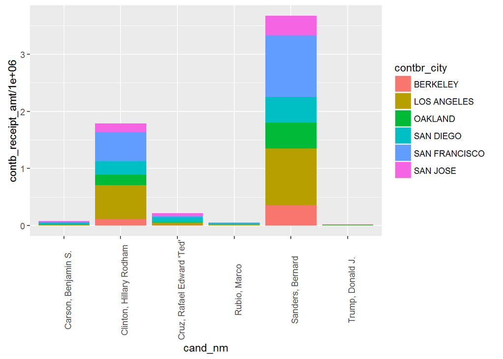

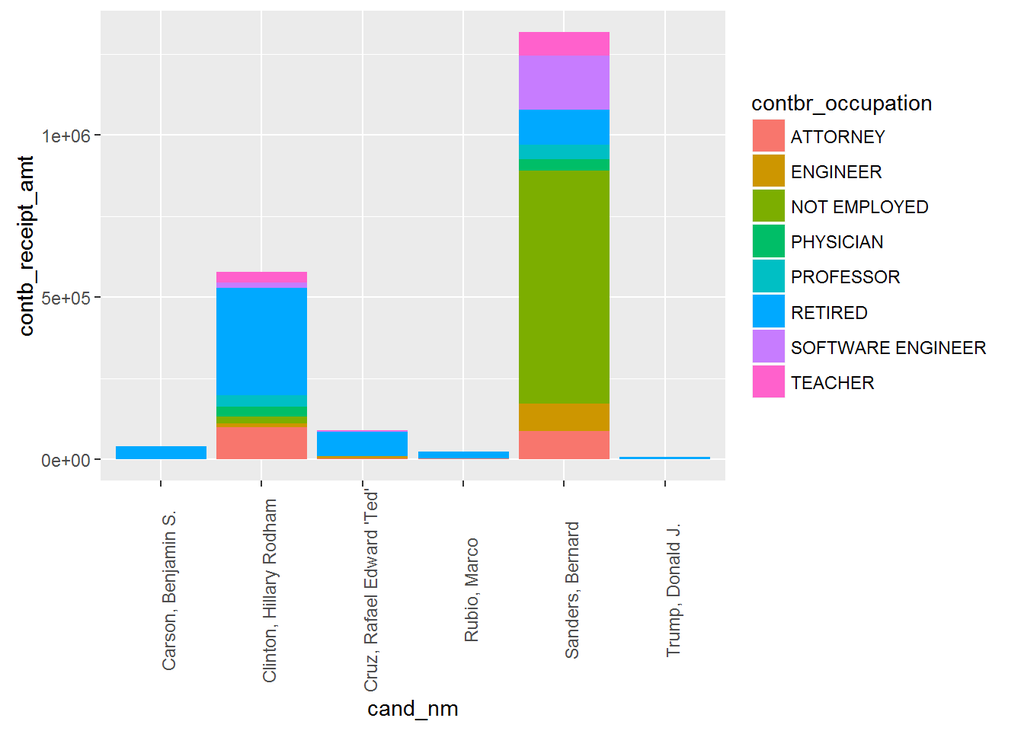

As expected, Bernard Sanders and Hillary Clinton received most amount of contribution and from Los Angeles/ San Francisco cities.

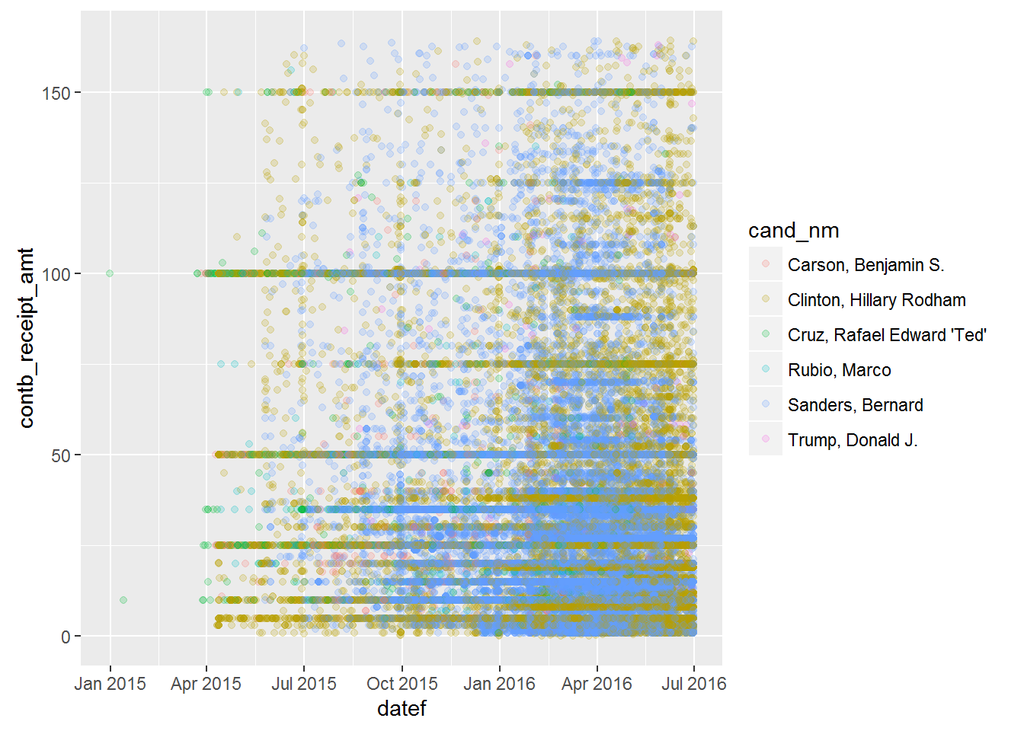

We see that most of contribution are in multiples of 5 and dominated by Sanders and Clinton.

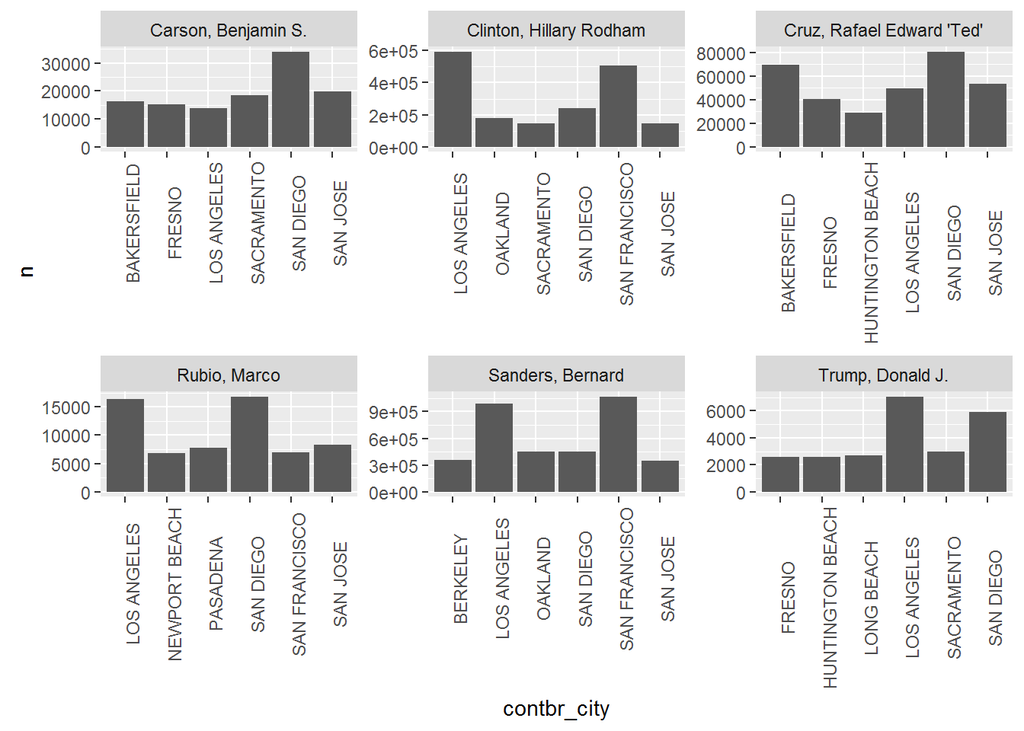

Here we plotted top 6 contributing cities of each of top 6 candidates.

# Multivariate Analysis

### Talk about some of the relationships you observed in this part of the investigation. Were there features that strengthened each other in terms of looking at your feature(s) of interest?

We found that contribution amounts are multiple of 5. Sanders started his campaign late, while Hillary has been active from earliest. Software engineers and unemployed seem most supportive of Sanders.

### Were there any interesting or surprising interactions between features?

We found that top cities are different for each candidate. While Cruz received most contributions from San Diego and Bakersfield, while Los Angeles is top contributing city overall.

### OPTIONAL: Did you create any models with your dataset? Discuss the strengths and limitations of your model.

# Final Plots and Summary

### Plot One

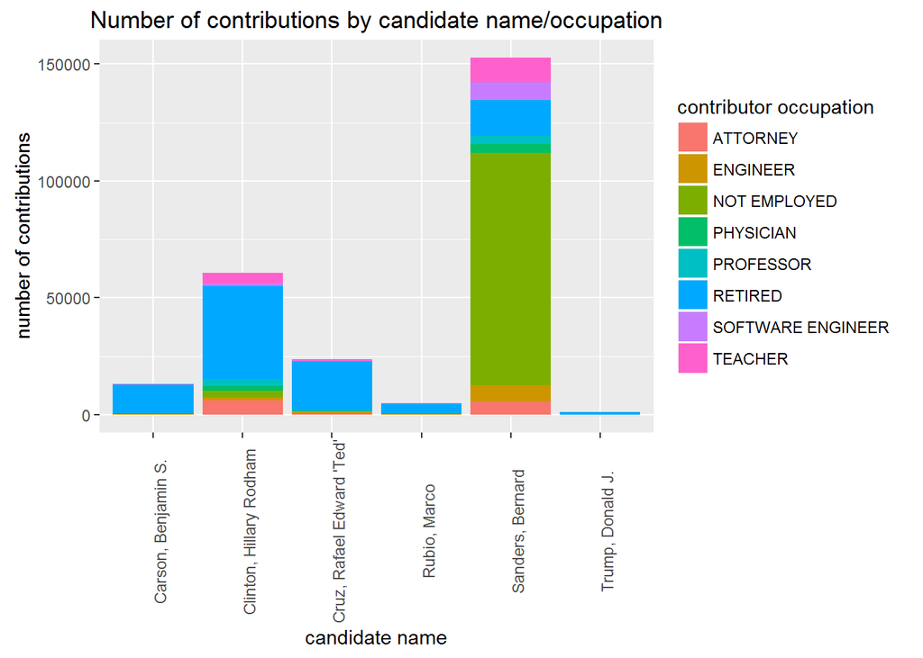

### Description One

Points to note in above plot are * Unemployed and retired are maximum contributors. * While most retired supports Hillary Clinton, Unemployed supports Bernard Sanders. * Most of engineers and software engineers also seem to support Sanders Bernard.

### Plot Two

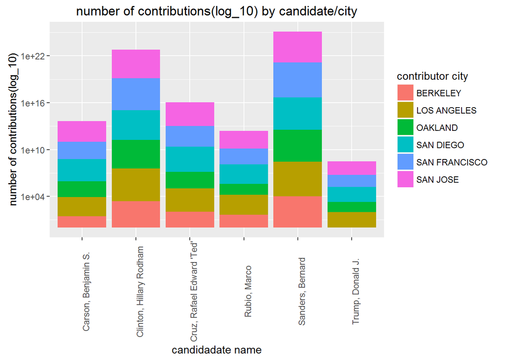

### Description Two

We note following points from plot

- Bernard Sanders received maximum number of contributions followed by Hillary Clinton.
- Donald Trump was at sixth position with meagre contributions.
- Los Angeles and San Francisco were major contributing cities.
- Donald Trump doesn’t seem to getting any contribution from Berkeley.

### Plot Three

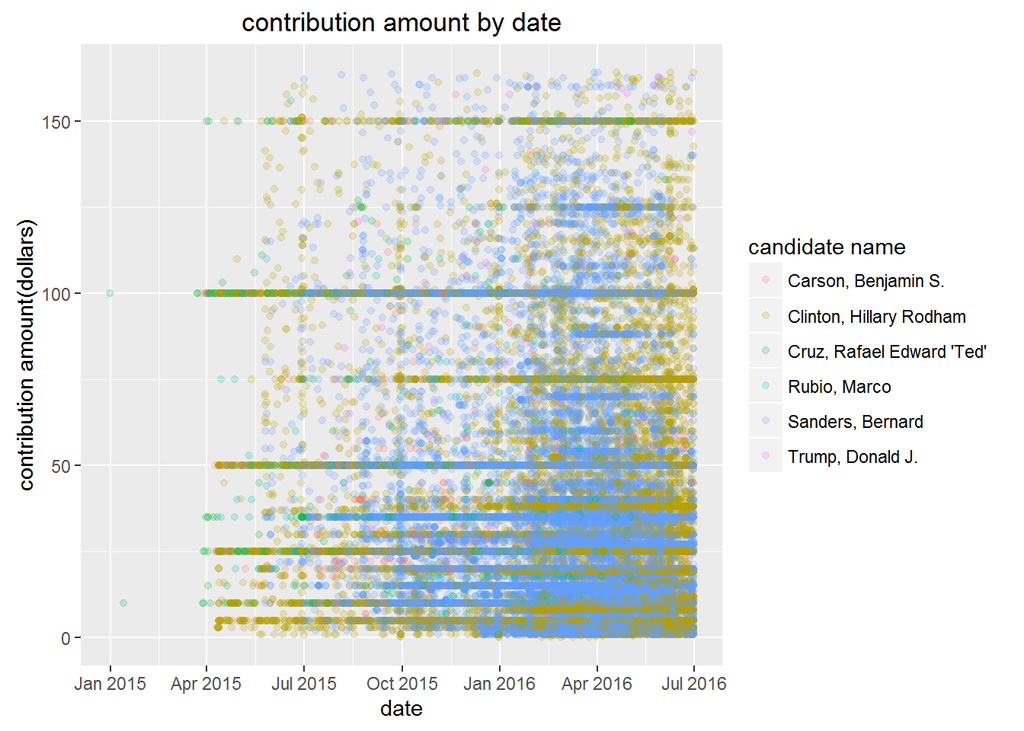

### Description Three

# Reflection

Most of contributions were concentrated on few candidates, cities and occupations. It was intractable, when I tried to explore all candidates, cities and occupations. To make data easier to explore and tractable, I found top candidates, cities and occupations and used them in analysis.  
I found that there were outliers in contribution amounts, which distorted my plots. To mitiagte this problem, I removed the outliers using interquantile range(IQR).  
I was also not able to directly plot date in given format for which I needed to convert them in R date type object.

In future, we could add other information like candidate party (Democratic/ Republican) and gender. We can also compare the data with other cities. We could also add population of cities to explain difference between cities contributions. We can also define important milestone in Presidential election to explain change in contributions with date. Also by using only top candidates to explore, we might have missed some important finding for other candidates which we can explore.